# Magnetis - Estudo de Conversão

Análise de performance do funil de conversão de novas pessoas investidoras.

**Objetivo**: Encontrar oportunidades para aumento da taxa de conversão no site.

**Etapas**:

- Conhecer a base de dados para saber quais os atributos disponiveis para estudo e a qualidade dos dados.
- Realizar análise exploratória para saber que tipo de perguntas podem ser respondidas.
- Formular hipóteses que expliquem o funil de conversão.
- Prognosticar ações para aumentar a taxa de cadastro de novas pessoas investidoras.

**Perguntas iniciais**:

- Há alguma diferença significativa entre cada etapa do funil por dispositivo? E por origem?
- O valor investido muda significativamente de acordo com a origem ou dispositivo?
- Há alguma hora do dia ou dia da semana mais comum para cadastros?
- Qual é a faixa de valores com maior número de simulações de investimento?
- Qual é o perfil de investidor que mais faz cadastros? E quais os objetivos definidos? E o perfil / objetivo com menor taxa de conversão?

[figure not shown]

## Preparação do ambiente

Para este estudo, faremos uso das bibliotecas pandas, matplotlib e seaborn.

```python
import pandas as pd
import matplotlib.pyplot as plt
import seaborn as sns
```

## Importação do arquivo de performance do funil

Os nomes das colunas serão alterados para facilitar a seleção de dados:

- Id: id
- Origem de Tráfego: source
- Dispositivo: device
- Página: page
- Valor Simulado: simulated_investment

```python
conversion_funnel = pd.read_csv('_data/navegacao_usuarios.csv', names=['id', 'source', 'device', 'page', 'simulated_investment'], header=0)
```

## Inspeção dos dados disponíveis para análise

```python
conversion_funnel.head()
```

|  | id | source | device | page | simulated_investment |
| --- | --- | --- | --- | --- | --- |
| 0 | 1 | Paid Search | desktop | 1 - Homepage | NaN |
| 1 | 2 | Paid Search | desktop | 1 - Homepage | NaN |
| 2 | 3 | Paid Search | desktop | 4 - Cadastro | 2000.0 |
| 3 | 3 | Paid Search | desktop | 1 - Homepage | 2000.0 |
| 4 | 3 | Paid Search | desktop | 3 - Plano de Investimentos | 2000.0 |

Há IDs duplicados. Cada linha representa um estágio do funil. Para fazer análises com dados agregados sem o ruído causado pelas linhas duplicadas, será criado um dataframe sem as duplicações. Este dataframe será usado para estudar as colunas source, device e simulated_investment. O dataframe original será usado para estudar o funil de conversão.

```python
conversion_funnel_unique = conversion_funnel.drop_duplicates(subset=['id']).drop('page', axis=1)
```

```python
conversion_funnel_unique.head()
```

|  | id | source | device | simulated_investment |
| --- | --- | --- | --- | --- |
| 0 | 1 | Paid Search | desktop | NaN |
| 1 | 2 | Paid Search | desktop | NaN |
| 2 | 3 | Paid Search | desktop | 2000.0 |
| 6 | 4 | Paid Search | desktop | NaN |
| 7 | 5 | Paid Search | desktop | NaN |

### Análise exploratória do funil de conversão

```python
conversion_funnel['page'].value_counts()
```

```
1 - Homepage                  10000
2 - Questionário               4166
3 - Plano de Investimentos     2506
4 - Cadastro                   1571
Name: page, dtype: int64
```

```python
conversion_funnel.groupby(['device', 'page']).agg({'id': ['count'], 'simulated_investment': ['sum', 'mean', 'median']})
```

| device | page | id count | simulated_investment sum | simulated_investment mean | simulated_investment median |
| --- | --- | --- | --- | --- | --- |
| desktop | 1 - Homepage | 7379 | 91612000.0 | 31384.720795 | 16000.0 |
|  | 2 - Questionário | 2919 | 91612000.0 | 31384.720795 | 16000.0 |
|  | 3 - Plano de Investimentos | 1772 | 73186000.0 | 41301.354402 | 20000.0 |
|  | 4 - Cadastro | 1228 | 62869000.0 | 51196.254072 | 22000.0 |
| mobile | 1 - Homepage | 2621 | 48302000.0 | 38734.562951 | 9000.0 |
|  | 2 - Questionário | 1247 | 48302000.0 | 38734.562951 | 9000.0 |
|  | 3 - Plano de Investimentos | 734 | 38260000.0 | 52125.340599 | 10000.0 |
|  | 4 - Cadastro | 343 | 13161000.0 | 38370.262391 | 20000.0 |

O valor médio da simulação de investimento aumenta a cada etapa do funil pra quem vem por desktop. No mobile, quem faz o cadastro o faz com valor médio de investimento menor do que quem montou o plano de investimentos, mas a mediana cresce. As medianas são todas distantes das médias ao longo do funil para ambos os tipos de dispositivo, sugerindo a presença de simulações com valores muito distantes da maioria (outliers). A presença de outliers é ainda mais acentuada em dispositivos mobile.

```python
conversion_by_device = pd.DataFrame({
    'desktop': conversion_funnel[conversion_funnel['device'] == 'desktop']['page'].value_counts(),
    'mobile': conversion_funnel[conversion_funnel['device'] == 'mobile']['page'].value_counts()
})
conversion_by_device
```

|  | desktop | mobile |
| --- | --- | --- |
| 1 - Homepage | 7379 | 2621 |
| 2 - Questionário | 2919 | 1247 |
| 3 - Plano de Investimentos | 1772 | 734 |
| 4 - Cadastro | 1228 | 343 |

A proporção de pessoas que inicia o questionário no mobile é maior do que no desktop, e após o questionário as proporções caem se comparadas ao desktop.

```python
conversion_funnel.groupby(['source', 'page']).agg({'id': ['count'], 'simulated_investment': ['sum', 'mean', 'median']})
```

| source | page | id count | simulated_investment sum | simulated_investment mean | simulated_investment median |
| --- | --- | --- | --- | --- | --- |
| Direct | 1 - Homepage | 2580 | 81492000.0 | 58291.845494 | 22000.0 |
|  | 2 - Questionário | 1519 | 81505000.0 | 53657.011192 | 20000.0 |
|  | 3 - Plano de Investimentos | 1151 | 74268000.0 | 64524.761077 | 22000.0 |
|  | 4 - Cadastro | 821 | 48570000.0 | 59159.561510 | 50000.0 |
| Organic Search | 1 - Homepage | 2547 | 33967000.0 | 27637.917006 | 20000.0 |
|  | 2 - Questionário | 1229 | 33319000.0 | 27110.659072 | 19000.0 |
|  | 3 - Plano de Investimentos | 724 | 20673000.0 | 28553.867403 | 15000.0 |
|  | 4 - Cadastro | 504 | 16643000.0 | 33021.825397 | 20000.0 |
| Paid Search | 1 - Homepage | 4445 | 18973000.0 | 15081.875994 | 5000.0 |
|  | 2 - Questionário | 1176 | 20029000.0 | 17031.462585 | 5000.0 |
|  | 3 - Plano de Investimentos | 539 | 13422000.0 | 24901.669759 | 5000.0 |
|  | 4 - Cadastro | 212 | 9677000.0 | 45646.226415 | 20000.0 |
| Social | 1 - Homepage | 428 | 5482000.0 | 19508.896797 | 12000.0 |
|  | 2 - Questionário | 242 | 5061000.0 | 20913.223140 | 13000.0 |
|  | 3 - Plano de Investimentos | 92 | 3083000.0 | 33510.869565 | 23500.0 |
|  | 4 - Cadastro | 34 | 1140000.0 | 33529.411765 | 20000.0 |

```python
conversion_by_source = pd.DataFrame({
    'Direct': conversion_funnel[conversion_funnel['source'] == 'Direct']['page'].value_counts(),
    'Organic Search': conversion_funnel[conversion_funnel['source'] == 'Organic Search']['page'].value_counts(),
    'Paid Search': conversion_funnel[conversion_funnel['source'] == 'Paid Search']['page'].value_counts(),
    'Social': conversion_funnel[conversion_funnel['source'] == 'Social']['page'].value_counts()
})
conversion_by_source
```

|  | Direct | Organic Search | Paid Search | Social |
| --- | --- | --- | --- | --- |
| 1 - Homepage | 2580 | 2547 | 4445 | 428 |
| 2 - Questionário | 1519 | 1229 | 1176 | 242 |
| 3 - Plano de Investimentos | 1151 | 724 | 539 | 92 |
| 4 - Cadastro | 821 | 504 | 212 | 34 |

A proporção de pessoas que finaliza o questionário é maior quando a pessoa vem por tráfego direto ou por busca orgânica do que pelas demais origens.

```python
conversion_funnel.groupby(['device', 'source', 'page']).agg({'id': 'count', 'simulated_investment': ['sum', 'mean', 'median']})
```

| device | source | page | id count | simulated_investment sum | simulated_investment mean | simulated_investment median |
| --- | --- | --- | --- | --- | --- | --- |
| desktop | Direct | 1 - Homepage | 1865 | 49280000.0 | 48031.189084 | 22000.0 |
|  |  | 2 - Questionário | 1109 | 50047000.0 | 45128.043282 | 22000.0 |
|  |  | 3 - Plano de Investimentos | 849 | 44847000.0 | 52823.321555 | 22000.0 |
|  |  | 4 - Cadastro | 682 | 41668000.0 | 61096.774194 | 50000.0 |
|  | Organic Search | 1 - Homepage | 1592 | 22768000.0 | 29189.743590 | 20000.0 |
|  |  | 2 - Questionário | 788 | 22695000.0 | 28800.761421 | 20000.0 |
|  |  | 3 - Plano de Investimentos | 491 | 16236000.0 | 33067.209776 | 20000.0 |
|  |  | 4 - Cadastro | 371 | 13096000.0 | 35299.191375 | 22000.0 |
|  | Paid Search | 1 - Homepage | 3533 | 14283000.0 | 16843.160377 | 5000.0 |
|  |  | 2 - Questionário | 799 | 14268000.0 | 17857.321652 | 5000.0 |
|  |  | 3 - Plano de Investimentos | 344 | 9071000.0 | 26369.186047 | 5000.0 |
|  |  | 4 - Cadastro | 142 | 6985000.0 | 49190.140845 | 22000.0 |
|  | Social | 1 - Homepage | 389 | 5281000.0 | 19928.301887 | 12000.0 |
|  |  | 2 - Questionário | 223 | 4602000.0 | 20636.771300 | 15000.0 |
|  |  | 3 - Plano de Investimentos | 88 | 3032000.0 | 34454.545455 | 25000.0 |
|  |  | 4 - Cadastro | 33 | 1120000.0 | 33939.393939 | 20000.0 |
| mobile | Direct | 1 - Homepage | 715 | 32212000.0 | 86591.397849 | 22000.0 |
|  |  | 2 - Questionário | 410 | 31458000.0 | 76726.829268 | 15000.0 |
|  |  | 3 - Plano de Investimentos | 302 | 29421000.0 | 97420.529801 | 12000.0 |
|  |  | 4 - Cadastro | 139 | 6902000.0 | 49654.676259 | 25000.0 |
|  | Organic Search | 1 - Homepage | 955 | 11199000.0 | 24942.093541 | 16000.0 |
|  |  | 2 - Questionário | 441 | 10624000.0 | 24090.702948 | 15000.0 |
|  |  | 3 - Plano de Investimentos | 233 | 4437000.0 | 19042.918455 | 11000.0 |
|  |  | 4 - Cadastro | 133 | 3547000.0 | 26669.172932 | 16000.0 |
|  | Paid Search | 1 - Homepage | 912 | 4690000.0 | 11439.024390 | 3000.0 |
|  |  | 2 - Questionário | 377 | 5761000.0 | 15281.167109 | 3000.0 |
|  |  | 3 - Plano de Investimentos | 195 | 4351000.0 | 22312.820513 | 4000.0 |
|  |  | 4 - Cadastro | 70 | 2692000.0 | 38457.142857 | 9000.0 |
|  | Social | 1 - Homepage | 39 | 201000.0 | 12562.500000 | 12000.0 |
|  |  | 2 - Questionário | 19 | 459000.0 | 24157.894737 | 12000.0 |
|  |  | 3 - Plano de Investimentos | 4 | 51000.0 | 12750.000000 | 11500.0 |
|  |  | 4 - Cadastro | 1 | 20000.0 | 20000.000000 | 20000.0 |

```python
pd.DataFrame({
    '1 - Homepage': conversion_funnel[conversion_funnel['page'] == '1 - Homepage'].groupby('source').agg({'simulated_investment': 'mean'})['simulated_investment'],
    '2 - Questionário': conversion_funnel[conversion_funnel['page'] == '2 - Questionário'].groupby('source').agg({'simulated_investment': 'mean'})['simulated_investment'],
    '3 - Plano de Investimentos': conversion_funnel[conversion_funnel['page'] == '3 - Plano de Investimentos'].groupby('source').agg({'simulated_investment': 'mean'})['simulated_investment'],
    '4 - Cadastro': conversion_funnel[conversion_funnel['page'] == '4 - Cadastro'].groupby('source').agg({'simulated_investment': 'mean'})['simulated_investment']
})
```

| source | 1 - Homepage | 2 - Questionário | 3 - Plano de Investimentos | 4 - Cadastro |
| --- | --- | --- | --- | --- |
| Direct | 58291.845494 | 53657.011192 | 64524.761077 | 59159.561510 |
| Organic Search | 27637.917006 | 27110.659072 | 28553.867403 | 33021.825397 |
| Paid Search | 15081.875994 | 17031.462585 | 24901.669759 | 45646.226415 |
| Social | 19508.896797 | 20913.223140 | 33510.869565 | 33529.411765 |

O tráfego que entrou por busca paga e busca orgânica investe mais, em média, do que simulou no questionário.

```python
conversion_funnel.groupby(['page']).agg({'id': ['count']})
```

| page | id count |
| --- | --- |
| 1 - Homepage | 10000 |
| 2 - Questionário | 4166 |
| 3 - Plano de Investimentos | 2506 |
| 4 - Cadastro | 1571 |

```python
conversion_funnel.groupby(['page']).agg({'simulated_investment': ['mean']})
```

| page | simulated_investment mean |
| --- | --- |
| 1 - Homepage | 33584.733557 |
| 2 - Questionário | 33584.733557 |
| 3 - Plano de Investimentos | 44471.667997 |
| 4 - Cadastro | 48395.926162 |

A média geral de simulações de investimento cresce a cada etapa do funil.

```python
'''
    @name set_bucket
    @description classifica cada simulação de investimento em faixas de valores
    @param simulated_investment float
    @return string
'''
def set_bucket(simulated_investment):
    if np.isnan(simulated_investment):
        return 'no investment'
    elif simulated_investment < 10000:
        return 'below 10.000'
    elif simulated_investment >= 10000 and simulated_investment < 20000:
        return 'between 10.000 and 19.999'
    elif simulated_investment >= 20000 and simulated_investment < 30000:
        return 'between 20.000 and 29.999'
    elif simulated_investment >= 30000 and simulated_investment < 40000:
        return 'between 30.000 and 39.999'
    elif simulated_investment >= 40000 and simulated_investment < 50000:
        return 'between 40.000 and 49.999'
    elif simulated_investment >= 50000 and simulated_investment < 60000:
        return 'between 50.000 and 59.999'
    elif simulated_investment >= 60000 and simulated_investment < 100000:
        return 'between 60.000 and 99.999'
    elif simulated_investment >= 100000 and simulated_investment < 150000:
        return 'between 100.000 and 149.999'
    elif simulated_investment >= 150000 and simulated_investment < 1000000:
        return 'between 150.000 and 999.999'
    else:
        return '1.000.000 or more'
```

```python
conversion_funnel['simulated_investment_range'] = conversion_funnel['simulated_investment'].apply(set_bucket)
```

```python
conversion_funnel.groupby(['page', 'simulated_investment_range']).agg({'id': 'count', 'simulated_investment': ['sum', 'mean']})
```

| page | simulated_investment_range | id count | simulated_investment sum | simulated_investment mean |
| --- | --- | --- | --- | --- |
| 1 - Homepage | 1.000.000 or more | 21 | 21000000.0 | 1000000.000000 |
|  | below 10.000 | 1753 | 6822000.0 | 3891.614375 |
|  | between 10.000 and 19.999 | 583 | 7703000.0 | 13212.692967 |
|  | between 100.000 and 149.999 | 637 | 67130000.0 | 105384.615385 |
|  | between 150.000 and 999.999 | 10 | 2200000.0 | 220000.000000 |
|  | between 20.000 and 29.999 | 737 | 15679000.0 | 21274.084125 |
|  | between 30.000 and 39.999 | 56 | 1680000.0 | 30000.000000 |
|  | between 40.000 and 49.999 | 78 | 3120000.0 | 40000.000000 |
|  | between 50.000 and 59.999 | 288 | 14400000.0 | 50000.000000 |
|  | between 60.000 and 99.999 | 3 | 180000.0 | 60000.000000 |
|  | no investment | 5834 | 0.0 | NaN |
| 2 - Questionário | 1.000.000 or more | 21 | 21000000.0 | 1000000.000000 |
|  | below 10.000 | 1753 | 6822000.0 | 3891.614375 |
|  | between 10.000 and 19.999 | 583 | 7703000.0 | 13212.692967 |
|  | between 100.000 and 149.999 | 637 | 67130000.0 | 105384.615385 |
|  | between 150.000 and 999.999 | 10 | 2200000.0 | 220000.000000 |
|  | between 20.000 and 29.999 | 737 | 15679000.0 | 21274.084125 |
|  | between 30.000 and 39.999 | 56 | 1680000.0 | 30000.000000 |
|  | between 40.000 and 49.999 | 78 | 3120000.0 | 40000.000000 |
|  | between 50.000 and 59.999 | 288 | 14400000.0 | 50000.000000 |
|  | between 60.000 and 99.999 | 3 | 180000.0 | 60000.000000 |
| 3 - Plano de Investimentos | 1.000.000 or more | 21 | 21000000.0 | 1000000.000000 |
|  | below 10.000 | 842 | 3899000.0 | 4630.641330 |
|  | between 10.000 and 19.999 | 385 | 4803000.0 | 12475.324675 |
|  | between 100.000 and 149.999 | 550 | 58180000.0 | 105781.818182 |
|  | between 150.000 and 999.999 | 10 | 2200000.0 | 220000.000000 |
|  | between 20.000 and 29.999 | 464 | 9944000.0 | 21431.034483 |
|  | between 30.000 and 39.999 | 10 | 300000.0 | 30000.000000 |
|  | between 40.000 and 49.999 | 11 | 440000.0 | 40000.000000 |
|  | between 50.000 and 59.999 | 210 | 10500000.0 | 50000.000000 |
|  | between 60.000 and 99.999 | 3 | 180000.0 | 60000.000000 |
| 4 - Cadastro | below 10.000 | 364 | 2206000.0 | 6060.439560 |
|  | between 10.000 and 19.999 | 186 | 2538000.0 | 13645.161290 |
|  | between 100.000 and 149.999 | 508 | 53980000.0 | 106259.842520 |
|  | between 150.000 and 999.999 | 9 | 1800000.0 | 200000.000000 |
|  | between 20.000 and 29.999 | 333 | 7096000.0 | 21309.309309 |
|  | between 30.000 and 39.999 | 8 | 240000.0 | 30000.000000 |
|  | between 40.000 and 49.999 | 1 | 40000.0 | 40000.000000 |
|  | between 50.000 and 59.999 | 159 | 7950000.0 | 50000.000000 |
|  | between 60.000 and 99.999 | 3 | 180000.0 | 60000.000000 |

21 pessoas simularam investimento de **R\$ 1.000.000,00** ou mais. Todas responderam o questionário e passaram pela etapa de definição de plano de investimentos mas nenhuma fez o cadastro.

```python
conversion_funnel[conversion_funnel['device'] == 'desktop'].groupby(['device','page', 'simulated_investment_range']).agg({'id': 'count', 'simulated_investment': ['sum', 'mean', 'median']})
```

| device | page | simulated_investment_range | id count | simulated_investment sum | simulated_investment mean | simulated_investment median |
| --- | --- | --- | --- | --- | --- | --- |
| desktop | 1 - Homepage | below 10.000 | 1124 | 5093000.0 | 4531.138790 | 5000.0 |
|  |  | between 10.000 and 19.999 | 430 | 5745000.0 | 13360.465116 | 13000.0 |
|  |  | between 100.000 and 149.999 | 523 | 55600000.0 | 106309.751434 | 100000.0 |
|  |  | between 150.000 and 999.999 | 2 | 600000.0 | 300000.000000 | 300000.0 |
|  |  | between 20.000 and 29.999 | 569 | 12074000.0 | 21219.683656 | 20000.0 |
|  |  | between 30.000 and 39.999 | 49 | 1470000.0 | 30000.000000 | 30000.0 |
|  |  | between 40.000 and 49.999 | 10 | 400000.0 | 40000.000000 | 40000.0 |
|  |  | between 50.000 and 59.999 | 209 | 10450000.0 | 50000.000000 | 50000.0 |
|  |  | between 60.000 and 99.999 | 3 | 180000.0 | 60000.000000 | 60000.0 |
|  |  | no investment | 4460 | 0.0 | NaN | NaN |
|  | 2 - Questionário | below 10.000 | 1124 | 5093000.0 | 4531.138790 | 5000.0 |
|  |  | between 10.000 and 19.999 | 430 | 5745000.0 | 13360.465116 | 13000.0 |
|  |  | between 100.000 and 149.999 | 523 | 55600000.0 | 106309.751434 | 100000.0 |
|  |  | between 150.000 and 999.999 | 2 | 600000.0 | 300000.000000 | 300000.0 |
|  |  | between 20.000 and 29.999 | 569 | 12074000.0 | 21219.683656 | 20000.0 |
|  |  | between 30.000 and 39.999 | 49 | 1470000.0 | 30000.000000 | 30000.0 |
|  |  | between 40.000 and 49.999 | 10 | 400000.0 | 40000.000000 | 40000.0 |
|  |  | between 50.000 and 59.999 | 209 | 10450000.0 | 50000.000000 | 50000.0 |
|  |  | between 60.000 and 99.999 | 3 | 180000.0 | 60000.000000 | 60000.0 |
|  | 3 - Plano de Investimentos | below 10.000 | 478 | 2575000.0 | 5387.029289 | 5000.0 |
|  |  | between 10.000 and 19.999 | 257 | 3143000.0 | 12229.571984 | 11000.0 |
|  |  | between 100.000 and 149.999 | 468 | 49860000.0 | 106538.461538 | 100000.0 |
|  |  | between 150.000 and 999.999 | 2 | 600000.0 | 300000.000000 | 300000.0 |
|  |  | between 20.000 and 29.999 | 390 | 8288000.0 | 21251.282051 | 21000.0 |
|  |  | between 30.000 and 39.999 | 3 | 90000.0 | 30000.000000 | 30000.0 |
|  |  | between 40.000 and 49.999 | 10 | 400000.0 | 40000.000000 | 40000.0 |
|  |  | between 50.000 and 59.999 | 161 | 8050000.0 | 50000.000000 | 50000.0 |
|  |  | between 60.000 and 99.999 | 3 | 180000.0 | 60000.000000 | 60000.0 |
|  | 4 - Cadastro | below 10.000 | 249 | 1511000.0 | 6068.273092 | 7000.0 |
|  |  | between 10.000 and 19.999 | 133 | 1807000.0 | 13586.466165 | 15000.0 |
|  |  | between 100.000 and 149.999 | 443 | 47360000.0 | 106907.449210 | 100000.0 |
|  |  | between 150.000 and 999.999 | 1 | 200000.0 | 200000.000000 | 200000.0 |
|  |  | between 20.000 and 29.999 | 282 | 5981000.0 | 21209.219858 | 21000.0 |
|  |  | between 30.000 and 39.999 | 1 | 30000.0 | 30000.000000 | 30000.0 |
|  |  | between 50.000 and 59.999 | 116 | 5800000.0 | 50000.000000 | 50000.0 |
|  |  | between 60.000 and 99.999 | 3 | 180000.0 | 60000.000000 | 60000.0 |

```python
conversion_funnel[conversion_funnel['device'] == 'mobile'].groupby(['device', 'page', 'simulated_investment_range']).agg({'id': 'count', 'simulated_investment': ['sum', 'mean', 'median']})
```

| device | page | simulated_investment_range | id count | simulated_investment sum | simulated_investment mean | simulated_investment median |
| --- | --- | --- | --- | --- | --- | --- |
| mobile | 1 - Homepage | 1.000.000 or more | 21 | 21000000.0 | 1000000.000000 | 1000000.0 |
|  |  | below 10.000 | 629 | 1729000.0 | 2748.807631 | 2000.0 |
|  |  | between 10.000 and 19.999 | 153 | 1958000.0 | 12797.385621 | 12000.0 |
|  |  | between 100.000 and 149.999 | 114 | 11530000.0 | 101140.350877 | 100000.0 |
|  |  | between 150.000 and 999.999 | 8 | 1600000.0 | 200000.000000 | 200000.0 |
|  |  | between 20.000 and 29.999 | 168 | 3605000.0 | 21458.333333 | 20000.0 |
|  |  | between 30.000 and 39.999 | 7 | 210000.0 | 30000.000000 | 30000.0 |
|  |  | between 40.000 and 49.999 | 68 | 2720000.0 | 40000.000000 | 40000.0 |
|  |  | between 50.000 and 59.999 | 79 | 3950000.0 | 50000.000000 | 50000.0 |
|  |  | no investment | 1374 | 0.0 | NaN | NaN |
|  | 2 - Questionário | 1.000.000 or more | 21 | 21000000.0 | 1000000.000000 | 1000000.0 |
|  |  | below 10.000 | 629 | 1729000.0 | 2748.807631 | 2000.0 |
|  |  | between 10.000 and 19.999 | 153 | 1958000.0 | 12797.385621 | 12000.0 |
|  |  | between 100.000 and 149.999 | 114 | 11530000.0 | 101140.350877 | 100000.0 |
|  |  | between 150.000 and 999.999 | 8 | 1600000.0 | 200000.000000 | 200000.0 |
|  |  | between 20.000 and 29.999 | 168 | 3605000.0 | 21458.333333 | 20000.0 |
|  |  | between 30.000 and 39.999 | 7 | 210000.0 | 30000.000000 | 30000.0 |
|  |  | between 40.000 and 49.999 | 68 | 2720000.0 | 40000.000000 | 40000.0 |
|  |  | between 50.000 and 59.999 | 79 | 3950000.0 | 50000.000000 | 50000.0 |
|  | 3 - Plano de Investimentos | 1.000.000 or more | 21 | 21000000.0 | 1000000.000000 | 1000000.0 |
|  |  | below 10.000 | 364 | 1324000.0 | 3637.362637 | 3000.0 |
|  |  | between 10.000 and 19.999 | 128 | 1660000.0 | 12968.750000 | 12000.0 |
|  |  | between 100.000 and 149.999 | 82 | 8320000.0 | 101463.414634 | 100000.0 |
|  |  | between 150.000 and 999.999 | 8 | 1600000.0 | 200000.000000 | 200000.0 |
|  |  | between 20.000 and 29.999 | 74 | 1656000.0 | 22378.378378 | 22000.0 |
|  |  | between 30.000 and 39.999 | 7 | 210000.0 | 30000.000000 | 30000.0 |
|  |  | between 40.000 and 49.999 | 1 | 40000.0 | 40000.000000 | 40000.0 |
|  |  | between 50.000 and 59.999 | 49 | 2450000.0 | 50000.000000 | 50000.0 |
|  | 4 - Cadastro | below 10.000 | 115 | 695000.0 | 6043.478261 | 7000.0 |
|  |  | between 10.000 and 19.999 | 53 | 731000.0 | 13792.452830 | 15000.0 |
|  |  | between 100.000 and 149.999 | 65 | 6620000.0 | 101846.153846 | 100000.0 |
|  |  | between 150.000 and 999.999 | 8 | 1600000.0 | 200000.000000 | 200000.0 |
|  |  | between 20.000 and 29.999 | 51 | 1115000.0 | 21862.745098 | 22000.0 |
|  |  | between 30.000 and 39.999 | 7 | 210000.0 | 30000.000000 | 30000.0 |
|  |  | between 40.000 and 49.999 | 1 | 40000.0 | 40000.000000 | 40000.0 |
|  |  | between 50.000 and 59.999 | 43 | 2150000.0 | 50000.000000 | 50000.0 |

```python
conversion_funnel[conversion_funnel['source'] == 'Direct'].groupby(['source', 'page', 'simulated_investment_range']).agg({'id': 'count', 'simulated_investment': ['sum', 'mean']})
```

| source | page | simulated_investment_range | id count | simulated_investment sum | simulated_investment mean |
| --- | --- | --- | --- | --- | --- |
| Direct | 1 - Homepage | 1.000.000 or more | 21 | 21000000.0 | 1000000.000000 |
|  |  | below 10.000 | 348 | 1249000.0 | 3589.080460 |
|  |  | between 10.000 and 19.999 | 181 | 2227000.0 | 12303.867403 |
|  |  | between 100.000 and 149.999 | 378 | 40910000.0 | 108227.513228 |
|  |  | between 150.000 and 999.999 | 10 | 2200000.0 | 220000.000000 |
|  |  | between 20.000 and 29.999 | 265 | 5686000.0 | 21456.603774 |
|  |  | between 30.000 and 39.999 | 44 | 1320000.0 | 30000.000000 |
|  |  | between 40.000 and 49.999 | 68 | 2720000.0 | 40000.000000 |
|  |  | between 50.000 and 59.999 | 80 | 4000000.0 | 50000.000000 |
|  |  | between 60.000 and 99.999 | 3 | 180000.0 | 60000.000000 |
|  |  | no investment | 1182 | 0.0 | NaN |
|  | 2 - Questionário | 1.000.000 or more | 20 | 20000000.0 | 1000000.000000 |
|  |  | below 10.000 | 439 | 1552000.0 | 3535.307517 |
|  |  | between 10.000 and 19.999 | 195 | 2408000.0 | 12348.717949 |
|  |  | between 100.000 and 149.999 | 381 | 41170000.0 | 108057.742782 |
|  |  | between 150.000 and 999.999 | 10 | 2200000.0 | 220000.000000 |
|  |  | between 20.000 and 29.999 | 284 | 6085000.0 | 21426.056338 |
|  |  | between 30.000 and 39.999 | 41 | 1230000.0 | 30000.000000 |
|  |  | between 40.000 and 49.999 | 62 | 2480000.0 | 40000.000000 |
|  |  | between 50.000 and 59.999 | 84 | 4200000.0 | 50000.000000 |
|  |  | between 60.000 and 99.999 | 3 | 180000.0 | 60000.000000 |
|  | 3 - Plano de Investimentos | 1.000.000 or more | 20 | 20000000.0 | 1000000.000000 |
|  |  | below 10.000 | 231 | 1046000.0 | 4528.138528 |
|  |  | between 10.000 and 19.999 | 170 | 2133000.0 | 12547.058824 |
|  |  | between 100.000 and 149.999 | 356 | 38620000.0 | 108483.146067 |
|  |  | between 150.000 and 999.999 | 10 | 2200000.0 | 220000.000000 |
|  |  | between 20.000 and 29.999 | 272 | 5809000.0 | 21356.617647 |
|  |  | between 30.000 and 39.999 | 7 | 210000.0 | 30000.000000 |
|  |  | between 40.000 and 49.999 | 3 | 120000.0 | 40000.000000 |
|  |  | between 50.000 and 59.999 | 79 | 3950000.0 | 50000.000000 |
|  |  | between 60.000 and 99.999 | 3 | 180000.0 | 60000.000000 |
|  | 4 - Cadastro | below 10.000 | 141 | 837000.0 | 5936.170213 |
|  |  | between 10.000 and 19.999 | 79 | 1099000.0 | 13911.392405 |
|  |  | between 100.000 and 149.999 | 344 | 37410000.0 | 108750.000000 |
|  |  | between 150.000 and 999.999 | 8 | 1600000.0 | 200000.000000 |
|  |  | between 20.000 and 29.999 | 164 | 3494000.0 | 21304.878049 |
|  |  | between 30.000 and 39.999 | 7 | 210000.0 | 30000.000000 |
|  |  | between 40.000 and 49.999 | 1 | 40000.0 | 40000.000000 |
|  |  | between 50.000 and 59.999 | 74 | 3700000.0 | 50000.000000 |
|  |  | between 60.000 and 99.999 | 3 | 180000.0 | 60000.000000 |

Simulações de investimento abaixo de R\$ 10.000,00 são mais comuns no questionário para quem veio por tráfego direto, porém é mais comum que o valor simulado de quem faça o cadastro seja entre R\\$ 100.000,00 e R\$ 150.000,00.

```python
conversion_funnel[conversion_funnel['source'] == 'Organic Search'].groupby(['source', 'page', 'simulated_investment_range']).agg({'id': 'count', 'simulated_investment': ['sum', 'mean']})
```

| source | page | simulated_investment_range | id count | simulated_investment sum | simulated_investment mean |
| --- | --- | --- | --- | --- | --- |
| Organic Search | 1 - Homepage | below 10.000 | 272 | 1115000.0 | 4099.264706 |
|  |  | between 10.000 and 19.999 | 318 | 4418000.0 | 13893.081761 |
|  |  | between 100.000 and 149.999 | 132 | 13200000.0 | 100000.000000 |
|  |  | between 20.000 and 29.999 | 350 | 7384000.0 | 21097.142857 |
|  |  | between 50.000 and 59.999 | 157 | 7850000.0 | 50000.000000 |
|  |  | no investment | 1318 | 0.0 | NaN |
|  | 2 - Questionário | below 10.000 | 311 | 1297000.0 | 4170.418006 |
|  |  | between 10.000 and 19.999 | 309 | 4279000.0 | 13847.896440 |
|  |  | between 100.000 and 149.999 | 135 | 13540000.0 | 100296.296296 |
|  |  | between 20.000 and 29.999 | 328 | 6923000.0 | 21106.707317 |
|  |  | between 40.000 and 49.999 | 2 | 80000.0 | 40000.000000 |
|  |  | between 50.000 and 59.999 | 144 | 7200000.0 | 50000.000000 |
|  | 3 - Plano de Investimentos | below 10.000 | 220 | 1078000.0 | 4900.000000 |
|  |  | between 10.000 and 19.999 | 181 | 2240000.0 | 12375.690608 |
|  |  | between 100.000 and 149.999 | 99 | 9970000.0 | 100707.070707 |
|  |  | between 20.000 and 29.999 | 134 | 2885000.0 | 21529.850746 |
|  |  | between 50.000 and 59.999 | 90 | 4500000.0 | 50000.000000 |
|  | 4 - Cadastro | below 10.000 | 132 | 840000.0 | 6363.636364 |
|  |  | between 10.000 and 19.999 | 93 | 1247000.0 | 13408.602151 |
|  |  | between 100.000 and 149.999 | 83 | 8400000.0 | 101204.819277 |
|  |  | between 150.000 and 999.999 | 1 | 200000.0 | 200000.000000 |
|  |  | between 20.000 and 29.999 | 133 | 2856000.0 | 21473.684211 |
|  |  | between 50.000 and 59.999 | 62 | 3100000.0 | 50000.000000 |

Visitas por busca orgânica tendem a simular e a cadastrar simulações de investimento menores do que tráfego direto, com valores de até R\$ 20.000,00.

```python
conversion_funnel[conversion_funnel['source'] == 'Paid Search'].groupby(['source', 'page', 'simulated_investment_range']).agg({'id': 'count', 'simulated_investment': ['sum', 'mean']})
```

| source | page | simulated_investment_range | id count | simulated_investment sum | simulated_investment mean |
| --- | --- | --- | --- | --- | --- |
| Paid Search | 1 - Homepage | below 10.000 | 1037 | 4175000.0 | 4026.036644 |
|  |  | between 10.000 and 19.999 | 21 | 293000.0 | 13952.380952 |
|  |  | between 100.000 and 149.999 | 120 | 12250000.0 | 102083.333333 |
|  |  | between 20.000 and 29.999 | 61 | 1305000.0 | 21393.442623 |
|  |  | between 50.000 and 59.999 | 19 | 950000.0 | 50000.000000 |
|  |  | no investment | 3187 | 0.0 | NaN |
|  | 2 - Questionário | 1.000.000 or more | 1 | 1000000.0 | 1000000.000000 |
|  |  | below 10.000 | 926 | 3750000.0 | 4049.676026 |
|  |  | between 10.000 and 19.999 | 25 | 362000.0 | 14480.000000 |
|  |  | between 100.000 and 149.999 | 113 | 11550000.0 | 102212.389381 |
|  |  | between 20.000 and 29.999 | 71 | 1517000.0 | 21366.197183 |
|  |  | between 30.000 and 39.999 | 4 | 120000.0 | 30000.000000 |
|  |  | between 40.000 and 49.999 | 7 | 280000.0 | 40000.000000 |
|  |  | between 50.000 and 59.999 | 29 | 1450000.0 | 50000.000000 |
|  | 3 - Plano de Investimentos | 1.000.000 or more | 1 | 1000000.0 | 1000000.000000 |
|  |  | below 10.000 | 387 | 1760000.0 | 4547.803618 |
|  |  | between 10.000 and 19.999 | 21 | 294000.0 | 14000.000000 |
|  |  | between 100.000 and 149.999 | 88 | 8820000.0 | 100227.272727 |
|  |  | between 20.000 and 29.999 | 19 | 418000.0 | 22000.000000 |
|  |  | between 40.000 and 49.999 | 2 | 80000.0 | 40000.000000 |
|  |  | between 50.000 and 59.999 | 21 | 1050000.0 | 50000.000000 |
|  | 4 - Cadastro | below 10.000 | 91 | 529000.0 | 5813.186813 |
|  |  | between 10.000 and 19.999 | 14 | 192000.0 | 13714.285714 |
|  |  | between 100.000 and 149.999 | 78 | 7840000.0 | 100512.820513 |
|  |  | between 20.000 and 29.999 | 12 | 266000.0 | 22166.666667 |
|  |  | between 50.000 and 59.999 | 17 | 850000.0 | 50000.000000 |

O comportamento de simulações de visitantes vindos por mídia impulsionada é similar ao de tráfego direto: os valores simulados no topo do funil ficam abaixo de R\$ 10.000,00 mas ao chegar na etapa de cadastro, valores entre R\\$ 100.000,00 e R\$ 150.000,00 são o segundo intervalo mais comum.

```python
conversion_funnel[conversion_funnel['source'] == 'Social'].groupby(['source', 'page', 'simulated_investment_range']).agg({'id': 'count', 'simulated_investment': ['sum', 'mean']})
```

| source | page | simulated_investment_range | id count | simulated_investment sum | simulated_investment mean |
| --- | --- | --- | --- | --- | --- |
| Social | 1 - Homepage | below 10.000 | 96 | 283000.0 | 2947.916667 |
|  |  | between 10.000 and 19.999 | 63 | 765000.0 | 12142.857143 |
|  |  | between 100.000 and 149.999 | 7 | 770000.0 | 110000.000000 |
|  |  | between 20.000 and 29.999 | 61 | 1304000.0 | 21377.049180 |
|  |  | between 30.000 and 39.999 | 12 | 360000.0 | 30000.000000 |
|  |  | between 40.000 and 49.999 | 10 | 400000.0 | 40000.000000 |
|  |  | between 50.000 and 59.999 | 32 | 1600000.0 | 50000.000000 |
|  |  | no investment | 147 | 0.0 | NaN |
|  | 2 - Questionário | below 10.000 | 77 | 223000.0 | 2896.103896 |
|  |  | between 10.000 and 19.999 | 54 | 654000.0 | 12111.111111 |
|  |  | between 100.000 and 149.999 | 8 | 870000.0 | 108750.000000 |
|  |  | between 20.000 and 29.999 | 54 | 1154000.0 | 21370.370370 |
|  |  | between 30.000 and 39.999 | 11 | 330000.0 | 30000.000000 |
|  |  | between 40.000 and 49.999 | 7 | 280000.0 | 40000.000000 |
|  |  | between 50.000 and 59.999 | 31 | 1550000.0 | 50000.000000 |
|  | 3 - Plano de Investimentos | below 10.000 | 4 | 15000.0 | 3750.000000 |
|  |  | between 10.000 and 19.999 | 13 | 136000.0 | 10461.538462 |
|  |  | between 100.000 and 149.999 | 7 | 770000.0 | 110000.000000 |
|  |  | between 20.000 and 29.999 | 39 | 832000.0 | 21333.333333 |
|  |  | between 30.000 and 39.999 | 3 | 90000.0 | 30000.000000 |
|  |  | between 40.000 and 49.999 | 6 | 240000.0 | 40000.000000 |
|  |  | between 50.000 and 59.999 | 20 | 1000000.0 | 50000.000000 |
|  | 4 - Cadastro | between 100.000 and 149.999 | 3 | 330000.0 | 110000.000000 |
|  |  | between 20.000 and 29.999 | 24 | 480000.0 | 20000.000000 |
|  |  | between 30.000 and 39.999 | 1 | 30000.0 | 30000.000000 |
|  |  | between 50.000 and 59.999 | 6 | 300000.0 | 50000.000000 |

O tráfego que veio por redes sociais possui a menor partricipação de origens na amostra, mas o valor de investimento simulado de quem chega na etapa de cadastro tem uma tendência mais clara que as demais origens de ficar na faixa entre R\$ 20.000,00 e R\\$ 30.000,00.

### Análise exploratória de origens, dispositivos e valores simulados

```python
conversion_funnel_unique.info()
```

```
<class 'pandas.core.frame.DataFrame'>
Int64Index: 10000 entries, 0 to 18239
Data columns (total 4 columns):
 #   Column                Non-Null Count  Dtype
---  ------                --------------  -----
 0   id                    10000 non-null  int64
 1   source                10000 non-null  object
 2   device                10000 non-null  object
 3   simulated_investment  4166 non-null   float64
dtypes: float64(1), int64(1), object(2)
memory usage: 390.6+ KB
```

A única coluna com dados nulos é a de valor simulado.

```python
conversion_funnel_unique.describe()
```

|  | id | simulated_investment |
| --- | --- | --- |
| count | 10000.000000 | 4166.000000 |
| mean | 19648.169800 | 33584.733557 |
| std | 9530.425416 | 77979.480770 |
| min | 1.000000 | 1000.000000 |
| 25% | 9987.750000 | 5000.000000 |
| 50% | 22654.500000 | 14000.000000 |
| 75% | 26065.250000 | 30000.000000 |
| max | 32299.000000 | 1000000.000000 |

O menor valor simulado foi de **R\$ 1.000,00** e o maior de **R\$ 1.000.000,00**. A mediana é de **R$ 14.000,00** e a média é **R\$ 33.584,73**, indicando que os valores de simulação são bem diversos e que há valores extremos (outliers).

```python
conversion_funnel_unique['simulated_investment'].value_counts()
```

```
100000.0     421
1000.0       416
20000.0      390
5000.0       358
2000.0       301
50000.0      288
22000.0      192
4000.0       170
9000.0       168
10000.0      156
3000.0       118
110000.0     109
6000.0       105
12000.0      100
25000.0      100
7000.0        98
120000.0      87
15000.0       85
40000.0       78
17000.0       63
30000.0       56
21000.0       55
11000.0       47
16000.0       43
14000.0       32
19000.0       23
13000.0       21
1000000.0     21
130000.0      20
8000.0        19
18000.0       13
200000.0       9
60000.0        3
400000.0       1
Name: simulated_investment, dtype: int64
```

```python
df_info = pd.DataFrame({
    'percentage': conversion_funnel_unique['simulated_investment'].value_counts() / conversion_funnel_unique['simulated_investment'].count()
}).reset_index()
df_info.rename(columns={'index': 'simulated_investment'}, inplace=True)
```

```python
df_info[:6]['percentage'].sum()
```

```
0.5218434949591935
```

Os valores mais simulados são de **R\$ 100.000,00**, **R\$ 1.000,00**, **R\$ 20.000,00**, **R\$ 5.000,00**, **R\$ 2.000,00** e **R\$ 50.000,00**. Juntos, estes valores representam **52,18%** de todas as simulações de investimento.

```python
conversion_funnel_unique['simulated_investment'].value_counts().reset_index().sort_values(by=['index'], ascending=False)
```

|  | index | simulated_investment |
| --- | --- | --- |
| 27 | 1000000.0 | 21 |
| 33 | 400000.0 | 1 |
| 31 | 200000.0 | 9 |
| 28 | 130000.0 | 20 |
| 16 | 120000.0 | 87 |
| 11 | 110000.0 | 109 |
| 0 | 100000.0 | 421 |
| 32 | 60000.0 | 3 |
| 5 | 50000.0 | 288 |
| 18 | 40000.0 | 78 |
| 20 | 30000.0 | 56 |
| 14 | 25000.0 | 100 |
| 6 | 22000.0 | 192 |
| 21 | 21000.0 | 55 |
| 2 | 20000.0 | 390 |
| 25 | 19000.0 | 23 |
| 30 | 18000.0 | 13 |
| 19 | 17000.0 | 63 |
| 23 | 16000.0 | 43 |
| 17 | 15000.0 | 85 |
| 24 | 14000.0 | 32 |
| 26 | 13000.0 | 21 |
| 13 | 12000.0 | 100 |
| 22 | 11000.0 | 47 |
| 9 | 10000.0 | 156 |
| 8 | 9000.0 | 168 |
| 29 | 8000.0 | 19 |
| 15 | 7000.0 | 98 |
| 12 | 6000.0 | 105 |
| 3 | 5000.0 | 358 |
| 7 | 4000.0 | 170 |
| 10 | 3000.0 | 118 |
| 4 | 2000.0 | 301 |
| 1 | 1000.0 | 416 |

21 pessoas simularam investimentos de R\$ 1.000.000,00.

```python
conversion_funnel_unique[conversion_funnel_unique['simulated_investment'] != 1000000].describe()
```

|  | id | simulated_investment |
| --- | --- | --- |
| count | 9979.000000 | 4145.00000 |
| mean | 19646.253633 | 28688.54041 |
| std | 9540.357501 | 36806.76776 |
| min | 1.000000 | 1000.00000 |
| 25% | 9982.500000 | 5000.00000 |
| 50% | 22665.000000 | 13000.00000 |
| 75% | 26070.500000 | 30000.00000 |
| max | 32299.000000 | 400000.00000 |

```python
conversion_funnel_unique.describe()
```

|  | id | simulated_investment |
| --- | --- | --- |
| count | 10000.000000 | 4166.000000 |
| mean | 19648.169800 | 33584.733557 |
| std | 9530.425416 | 77979.480770 |
| min | 1.000000 | 1000.000000 |
| 25% | 9987.750000 | 5000.000000 |
| 50% | 22654.500000 | 14000.000000 |
| 75% | 26065.250000 | 30000.000000 |
| max | 32299.000000 | 1000000.000000 |

Retirando os investimentos de R\$ 1.000.000,00, o desvio padrão cai pela metade e a média de investimentos cai cerca de R\\$ 5.000,00.

```python
conversion_funnel_unique['device'].value_counts() / conversion_funnel_unique['device'].count()
```

```
desktop    0.7378
mobile     0.2622
Name: device, dtype: float64
```

**73,78%** das visitas aconteceram em desktop e **26,22%** no mobile.

```python
conversion_funnel_unique['source'].value_counts() / conversion_funnel_unique['source'].count()
```

```
Paid Search       0.4367
Direct            0.2709
Organic Search    0.2525
Social            0.0399
Name: source, dtype: float64
```

**43,67%** das visitas vieram por mídia impulsionada, **27,09%** vieram por tráfego direto, **25,25%** vieram por busca orgânica e **3,99%** pelas redes sociais.

```python
conversion_funnel_unique.groupby(['source', 'device']).agg({'id': ['count'], 'simulated_investment': ['sum', 'mean', 'median']})
```

| source | device | id count | simulated_investment sum | simulated_investment mean | simulated_investment median |
| --- | --- | --- | --- | --- | --- |
| Direct | desktop | 1956 | 51449000.0 | 46059.982095 | 22000.0 |
|  | mobile | 753 | 32322000.0 | 78834.146341 | 18500.0 |
| Organic Search | desktop | 1573 | 23526000.0 | 30914.586071 | 20000.0 |
|  | mobile | 952 | 11982000.0 | 26865.470852 | 19500.0 |
| Paid Search | desktop | 3487 | 12356000.0 | 15406.483791 | 5000.0 |
|  | mobile | 880 | 3927000.0 | 10388.888889 | 3000.0 |
| Social | desktop | 362 | 4181000.0 | 17567.226891 | 12000.0 |
|  | mobile | 37 | 171000.0 | 12214.285714 | 12000.0 |

```python
conversion_funnel_unique[(conversion_funnel_unique['device'] == 'mobile') & (conversion_funnel_unique['source'] == 'Direct')]['id'].count() / conversion_funnel_unique[(conversion_funnel_unique['device'] == 'desktop') & (conversion_funnel_unique['source'] == 'Direct')]['id'].count()
```

```
0.38496932515337423
```

Visitantes mobile que entraram por tráfego direto representam 38,49% do volume de desktop mobile que vieram por esta mesma origem. Quem acessou o site por mobile e veio por tráfego direto fez, em média, simulações maiores do que as demais combinações de fonte de tráfego e dispositivo. A mediana das simulações, por outro lado, é bem mais baixa, indicando que há valores extremos (outliers) nas simulações de mobile por tráfego direto.

```python
conversion_funnel_unique['simulated_investment_range'] = conversion_funnel_unique['simulated_investment'].apply(set_bucket)
conversion_funnel_unique
```

|  | id | source | device | simulated_investment | simulated_investment_range |
| --- | --- | --- | --- | --- | --- |
| 0 | 1 | Paid Search | desktop | NaN | no investment |
| 1 | 2 | Paid Search | desktop | NaN | no investment |
| 2 | 3 | Paid Search | desktop | 2000.0 | below 10.000 |
| 6 | 4 | Paid Search | desktop | NaN | no investment |
| 7 | 5 | Paid Search | desktop | NaN | no investment |
| ... | ... | ... | ... | ... | ... |
| 18225 | 32295 | Direct | desktop | 120000.0 | between 100.000 and 149.999 |
| 18229 | 32296 | Direct | desktop | 120000.0 | between 100.000 and 149.999 |
| 18233 | 32297 | Direct | desktop | 120000.0 | between 100.000 and 149.999 |
| 18237 | 32298 | Direct | desktop | 50000.0 | between 50.000 and 59.999 |
| 18239 | 32299 | Direct | desktop | 120000.0 | between 100.000 and 149.999 |

10000 rows × 5 columns

```python
conversion_funnel_unique.groupby(['device', 'simulated_investment_range']).agg({'id': 'count', 'simulated_investment': ['sum', 'mean', 'median']})
```

| device | simulated_investment_range | id count | simulated_investment sum | simulated_investment mean | simulated_investment median |
| --- | --- | --- | --- | --- | --- |
| desktop | below 10.000 | 1124 | 5093000.0 | 4531.138790 | 5000.0 |
|  | between 10.000 and 19.999 | 430 | 5745000.0 | 13360.465116 | 13000.0 |
|  | between 100.000 and 149.999 | 522 | 55500000.0 | 106321.839080 | 100000.0 |
|  | between 150.000 and 999.999 | 2 | 600000.0 | 300000.000000 | 300000.0 |
|  | between 20.000 and 29.999 | 569 | 12074000.0 | 21219.683656 | 20000.0 |
|  | between 30.000 and 39.999 | 49 | 1470000.0 | 30000.000000 | 30000.0 |
|  | between 40.000 and 49.999 | 10 | 400000.0 | 40000.000000 | 40000.0 |
|  | between 50.000 and 59.999 | 209 | 10450000.0 | 50000.000000 | 50000.0 |
|  | between 60.000 and 99.999 | 3 | 180000.0 | 60000.000000 | 60000.0 |
|  | no investment | 4460 | 0.0 | NaN | NaN |
| mobile | 1.000.000 or more | 21 | 21000000.0 | 1000000.000000 | 1000000.0 |
|  | below 10.000 | 629 | 1729000.0 | 2748.807631 | 2000.0 |
|  | between 10.000 and 19.999 | 153 | 1958000.0 | 12797.385621 | 12000.0 |
|  | between 100.000 and 149.999 | 115 | 11630000.0 | 101130.434783 | 100000.0 |
|  | between 150.000 and 999.999 | 8 | 1600000.0 | 200000.000000 | 200000.0 |
|  | between 20.000 and 29.999 | 168 | 3605000.0 | 21458.333333 | 20000.0 |
|  | between 30.000 and 39.999 | 7 | 210000.0 | 30000.000000 | 30000.0 |
|  | between 40.000 and 49.999 | 68 | 2720000.0 | 40000.000000 | 40000.0 |
|  | between 50.000 and 59.999 | 79 | 3950000.0 | 50000.000000 | 50000.0 |
|  | no investment | 1374 | 0.0 | NaN | NaN |

Simulações de investimento entre R\$ 40.000,00 e R\\$ 50.000,00 são mais comuns em dispositivos mobile.

```python
conversion_funnel_unique.groupby(['source', 'simulated_investment_range']).agg({'id': 'count', 'simulated_investment': ['sum', 'mean', 'median']})
```

| source | simulated_investment_range | id count | simulated_investment sum | simulated_investment mean | simulated_investment median |
| --- | --- | --- | --- | --- | --- |
| Direct | 1.000.000 or more | 21 | 21000000.0 | 1000000.000000 | 1000000.0 |
|  | below 10.000 | 414 | 1543000.0 | 3727.053140 | 2000.0 |
|  | between 10.000 and 19.999 | 204 | 2553000.0 | 12514.705882 | 12000.0 |
|  | between 100.000 and 149.999 | 386 | 41610000.0 | 107797.927461 | 110000.0 |
|  | between 150.000 and 999.999 | 9 | 2000000.0 | 222222.222222 | 200000.0 |
|  | between 20.000 and 29.999 | 282 | 6045000.0 | 21436.170213 | 22000.0 |
|  | between 30.000 and 39.999 | 44 | 1320000.0 | 30000.000000 | 30000.0 |
|  | between 40.000 and 49.999 | 68 | 2720000.0 | 40000.000000 | 40000.0 |
|  | between 50.000 and 59.999 | 96 | 4800000.0 | 50000.000000 | 50000.0 |
|  | between 60.000 and 99.999 | 3 | 180000.0 | 60000.000000 | 60000.0 |
|  | no investment | 1182 | 0.0 | NaN | NaN |
| Organic Search | below 10.000 | 254 | 984000.0 | 3874.015748 | 3000.0 |
|  | between 10.000 and 19.999 | 300 | 4162000.0 | 13873.333333 | 15000.0 |
|  | between 100.000 and 149.999 | 152 | 15300000.0 | 100657.894737 | 100000.0 |
|  | between 150.000 and 999.999 | 1 | 200000.0 | 200000.000000 | 200000.0 |
|  | between 20.000 and 29.999 | 350 | 7362000.0 | 21034.285714 | 20000.0 |
|  | between 50.000 and 59.999 | 150 | 7500000.0 | 50000.000000 | 50000.0 |
|  | no investment | 1318 | 0.0 | NaN | NaN |
| Paid Search | below 10.000 | 989 | 4012000.0 | 4056.622851 | 4000.0 |
|  | between 10.000 and 19.999 | 18 | 243000.0 | 13500.000000 | 13500.0 |
|  | between 100.000 and 149.999 | 96 | 9890000.0 | 103020.833333 | 100000.0 |
|  | between 20.000 and 29.999 | 60 | 1288000.0 | 21466.666667 | 20000.0 |
|  | between 50.000 and 59.999 | 17 | 850000.0 | 50000.000000 | 50000.0 |
|  | no investment | 3187 | 0.0 | NaN | NaN |
| Social | below 10.000 | 96 | 283000.0 | 2947.916667 | 2000.0 |
|  | between 10.000 and 19.999 | 61 | 745000.0 | 12213.114754 | 12000.0 |
|  | between 100.000 and 149.999 | 3 | 330000.0 | 110000.000000 | 110000.0 |
|  | between 20.000 and 29.999 | 45 | 984000.0 | 21866.666667 | 20000.0 |
|  | between 30.000 and 39.999 | 12 | 360000.0 | 30000.000000 | 30000.0 |
|  | between 40.000 and 49.999 | 10 | 400000.0 | 40000.000000 | 40000.0 |
|  | between 50.000 and 59.999 | 25 | 1250000.0 | 50000.000000 | 50000.0 |
|  | no investment | 147 | 0.0 | NaN | NaN |

Quem entrou por busca orgânica fez mais simulações entre **R\$ 10.000,00** e **R\$ 20.000,00** do que as demais origens, cujos valores de simulação mais comuns foram abaixo de **R\$ 10.000,00**.

```python
conversion_funnel_unique[conversion_funnel_unique['source'] == 'Direct'].groupby(['source','device', 'simulated_investment_range']).agg({'id': 'count', 'simulated_investment': ['sum', 'mean', 'median']})
```

| source | device | simulated_investment_range | id count | simulated_investment sum | simulated_investment mean | simulated_investment median |
| --- | --- | --- | --- | --- | --- | --- |
| Direct | desktop | below 10.000 | 280 | 1144000.0 | 4085.714286 | 4000.0 |
|  |  | between 10.000 and 19.999 | 133 | 1677000.0 | 12609.022556 | 11000.0 |
|  |  | between 100.000 and 149.999 | 348 | 37720000.0 | 108390.804598 | 110000.0 |
|  |  | between 150.000 and 999.999 | 2 | 600000.0 | 300000.000000 | 300000.0 |
|  |  | between 20.000 and 29.999 | 231 | 4868000.0 | 21073.593074 | 20000.0 |
|  |  | between 30.000 and 39.999 | 37 | 1110000.0 | 30000.000000 | 30000.0 |
|  |  | between 50.000 and 59.999 | 83 | 4150000.0 | 50000.000000 | 50000.0 |
|  |  | between 60.000 and 99.999 | 3 | 180000.0 | 60000.000000 | 60000.0 |
|  |  | no investment | 839 | 0.0 | NaN | NaN |
|  | mobile | 1.000.000 or more | 21 | 21000000.0 | 1000000.000000 | 1000000.0 |
|  |  | below 10.000 | 134 | 399000.0 | 2977.611940 | 1000.0 |
|  |  | between 10.000 and 19.999 | 71 | 876000.0 | 12338.028169 | 12000.0 |
|  |  | between 100.000 and 149.999 | 38 | 3890000.0 | 102368.421053 | 100000.0 |
|  |  | between 150.000 and 999.999 | 7 | 1400000.0 | 200000.000000 | 200000.0 |
|  |  | between 20.000 and 29.999 | 51 | 1177000.0 | 23078.431373 | 22000.0 |
|  |  | between 30.000 and 39.999 | 7 | 210000.0 | 30000.000000 | 30000.0 |
|  |  | between 40.000 and 49.999 | 68 | 2720000.0 | 40000.000000 | 40000.0 |
|  |  | between 50.000 and 59.999 | 13 | 650000.0 | 50000.000000 | 50000.0 |
|  |  | no investment | 343 | 0.0 | NaN | NaN |

As 21 pessoas que simularam R\$ 1.000.000,00 o fizeram por mobile vindo por tráfego direto.

```python
conversion_funnel_unique[conversion_funnel_unique['source'] == 'Organic Search'].groupby(['source','device', 'simulated_investment_range']).agg({'id': 'count', 'simulated_investment': ['sum', 'mean', 'median']})
```

| source | device | simulated_investment_range | id count | simulated_investment sum | simulated_investment mean | simulated_investment median |
| --- | --- | --- | --- | --- | --- | --- |
| Organic Search | desktop | below 10.000 | 97 | 630000.0 | 6494.845361 | 7000.0 |
|  |  | between 10.000 and 19.999 | 234 | 3275000.0 | 13995.726496 | 15000.0 |
|  |  | between 100.000 and 149.999 | 97 | 9770000.0 | 100721.649485 | 100000.0 |
|  |  | between 20.000 and 29.999 | 236 | 5001000.0 | 21190.677966 | 21000.0 |
|  |  | between 50.000 and 59.999 | 97 | 4850000.0 | 50000.000000 | 50000.0 |
|  |  | no investment | 812 | 0.0 | NaN | NaN |
|  | mobile | below 10.000 | 157 | 354000.0 | 2254.777070 | 1000.0 |
|  |  | between 10.000 and 19.999 | 66 | 887000.0 | 13439.393939 | 14000.0 |
|  |  | between 100.000 and 149.999 | 55 | 5530000.0 | 100545.454545 | 100000.0 |
|  |  | between 150.000 and 999.999 | 1 | 200000.0 | 200000.000000 | 200000.0 |
|  |  | between 20.000 and 29.999 | 114 | 2361000.0 | 20710.526316 | 20000.0 |
|  |  | between 50.000 and 59.999 | 53 | 2650000.0 | 50000.000000 | 50000.0 |
|  |  | no investment | 506 | 0.0 | NaN | NaN |

```python
conversion_funnel_unique[conversion_funnel_unique['source'] == 'Paid Search'].groupby(['source','device', 'simulated_investment_range']).agg({'id': 'count', 'simulated_investment': ['sum', 'mean', 'median']})
```

| source | device | simulated_investment_range | id count | simulated_investment sum | simulated_investment mean | simulated_investment median |
| --- | --- | --- | --- | --- | --- | --- |
| Paid Search | desktop | below 10.000 | 651 | 3036000.0 | 4663.594470 | 5000.0 |
|  |  | between 10.000 and 19.999 | 15 | 199000.0 | 13266.666667 | 13000.0 |
|  |  | between 100.000 and 149.999 | 74 | 7680000.0 | 103783.783784 | 100000.0 |
|  |  | between 20.000 and 29.999 | 58 | 1241000.0 | 21396.551724 | 20000.0 |
|  |  | between 50.000 and 59.999 | 4 | 200000.0 | 50000.000000 | 50000.0 |
|  |  | no investment | 2685 | 0.0 | NaN | NaN |
|  | mobile | below 10.000 | 338 | 976000.0 | 2887.573964 | 2500.0 |
|  |  | between 10.000 and 19.999 | 3 | 44000.0 | 14666.666667 | 17000.0 |
|  |  | between 100.000 and 149.999 | 22 | 2210000.0 | 100454.545455 | 100000.0 |
|  |  | between 20.000 and 29.999 | 2 | 47000.0 | 23500.000000 | 23500.0 |
|  |  | between 50.000 and 59.999 | 13 | 650000.0 | 50000.000000 | 50000.0 |
|  |  | no investment | 502 | 0.0 | NaN | NaN |

```python
conversion_funnel_unique[conversion_funnel_unique['source'] == 'Social'].groupby(['source','device', 'simulated_investment_range']).agg({'id': 'count', 'simulated_investment': ['sum', 'mean', 'median']})
```

| source | device | simulated_investment_range | id count | simulated_investment sum | simulated_investment mean | simulated_investment median |
| --- | --- | --- | --- | --- | --- | --- |
| Social | desktop | below 10.000 | 96 | 283000.0 | 2947.916667 | 2000.0 |
|  |  | between 10.000 and 19.999 | 48 | 594000.0 | 12375.000000 | 12000.0 |
|  |  | between 100.000 and 149.999 | 3 | 330000.0 | 110000.000000 | 110000.0 |
|  |  | between 20.000 and 29.999 | 44 | 964000.0 | 21909.090909 | 20000.0 |
|  |  | between 30.000 and 39.999 | 12 | 360000.0 | 30000.000000 | 30000.0 |
|  |  | between 40.000 and 49.999 | 10 | 400000.0 | 40000.000000 | 40000.0 |
|  |  | between 50.000 and 59.999 | 25 | 1250000.0 | 50000.000000 | 50000.0 |
|  |  | no investment | 124 | 0.0 | NaN | NaN |
|  | mobile | between 10.000 and 19.999 | 13 | 151000.0 | 11615.384615 | 12000.0 |
|  |  | between 20.000 and 29.999 | 1 | 20000.0 | 20000.000000 | 20000.0 |
|  |  | no investment | 23 | 0.0 | NaN | NaN |

A menor porção do tráfego é de social. Dentro deste grupo, praticamente todas as simulações de investimento feitas por dispositivos mobile foram na mesma faixa de valores.

## Visualização dos dados

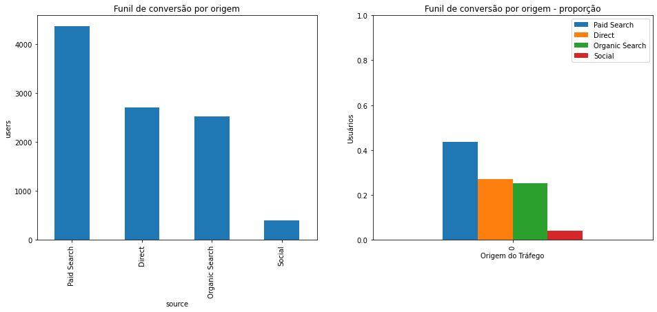

```python
fig, ax = plt.subplots(ncols=2, figsize=(16, 6))
conversion_funnel_unique['source'].value_counts().plot(ax=ax[0], kind='bar', title='Funil de conversão por origem', xlabel='source', ylabel='users')
pd.DataFrame({
    'Paid Search': [len(conversion_funnel_unique[conversion_funnel_unique['source'] == 'Paid Search']['source']) / len(conversion_funnel_unique['source'])],
    'Direct': [len(conversion_funnel_unique[conversion_funnel_unique['source'] == 'Direct']['source']) / len(conversion_funnel_unique['source'])],
    'Organic Search': [len(conversion_funnel_unique[conversion_funnel_unique['source'] == 'Organic Search']['source']) / len(conversion_funnel_unique['source'])],
    'Social': [len(conversion_funnel_unique[conversion_funnel_unique['source'] == 'Social']['source']) / len(conversion_funnel_unique['source'])]
}).plot(ax=ax[1], kind='bar', title='Funil de conversão por origem - proporção', xlabel='Origem do Tráfego', ylabel='Usuários', yticks=(0, .2, .4, .6, .8, 1))
```

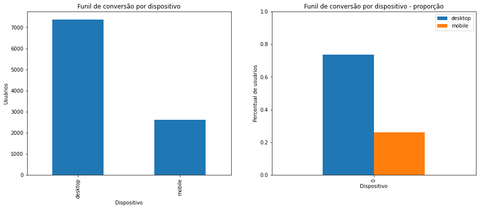

```python
fig, ax = plt.subplots(ncols=2, figsize=(16, 6))
conversion_funnel_unique['device'].value_counts().plot(ax=ax[0], kind='bar', title='Funil de conversão por dispositivo', xlabel='Dispositivo', ylabel='Usuários')
pd.DataFrame({
    'desktop': [len(conversion_funnel_unique[conversion_funnel_unique['device'] == 'desktop']['device']) / len(conversion_funnel_unique['device'])],
    'mobile': [len(conversion_funnel_unique[conversion_funnel_unique['device'] == 'mobile']['device']) / len(conversion_funnel_unique['device'])]
}).plot(ax=ax[1], kind='bar', title='Funil de conversão por dispositivo - proporção', xlabel='Dispositivo', ylabel='Percentual de usuários', yticks=(0, .2, .4, .6, .8, 1))
```

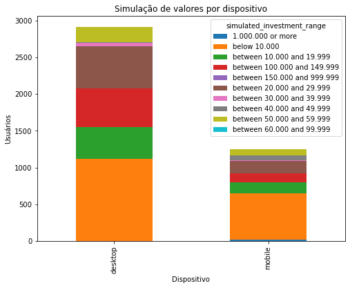

```python
conversion_funnel_unique[conversion_funnel_unique['simulated_investment_range'] != 'no investment'].groupby(['device', 'simulated_investment_range']).size().unstack().plot(kind='bar', stacked=True, title='Simulação de valores por dispositivo', xlabel='Dispositivo', ylabel='Usuários', figsize=(8, 6))
```

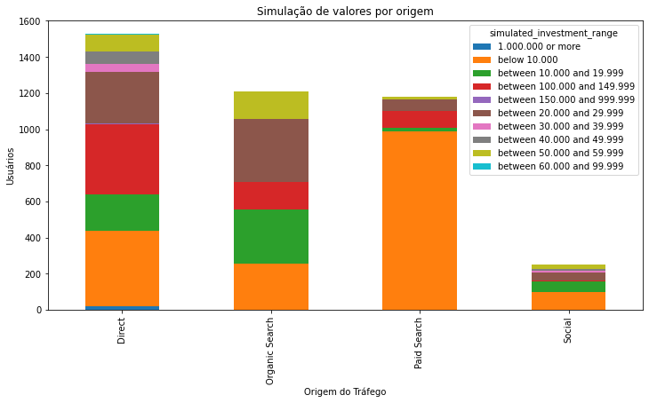

```python
conversion_funnel_unique[conversion_funnel_unique['simulated_investment_range'] != 'no investment'].groupby(['source', 'simulated_investment_range']).size().unstack().plot(kind='bar', stacked=True, title='Simulação de valores por origem', xlabel='Origem do Tráfego', ylabel='Usuários', figsize=(12, 6))
```

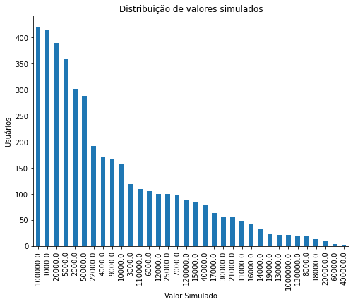

```python
conversion_funnel_unique['simulated_investment'].value_counts().plot(kind='bar', title='Distribuição de valores simulados', xlabel='Valor Simulado', ylabel='Usuários', figsize=(8, 6))
```

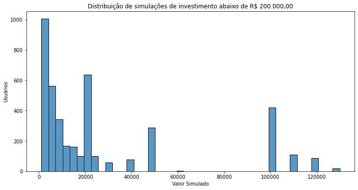

```python
fig, ax = plt.subplots(figsize=(12, 6))
p = sns.histplot(ax=ax, data=conversion_funnel_unique[(conversion_funnel_unique['simulated_investment'].notna()) & (conversion_funnel_unique['simulated_investment'] < 200000)], x='simulated_investment').set(title='Distribuição de simulações de investimento abaixo de R\\$ 200.000,00', xlabel='Valor Simulado', ylabel='Usuários')
```

Distribuição de simulações sem a presença de valores extremos. Os valores se concentram entre R\$ 1.000,00 e R\\$ 25.000,00.

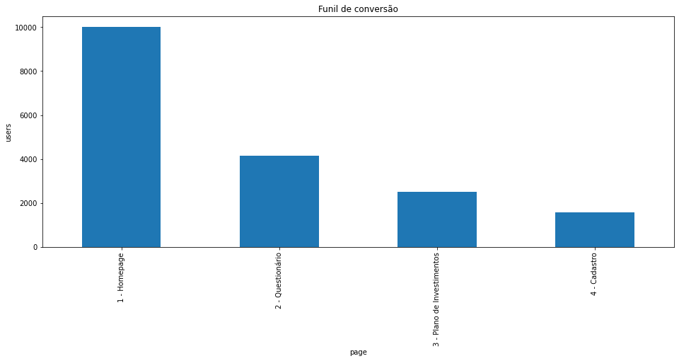

```python
conversion_funnel['page'].value_counts().plot(kind='bar', title='Funil de conversão', xlabel='page', ylabel='users', figsize=(16, 6))
```

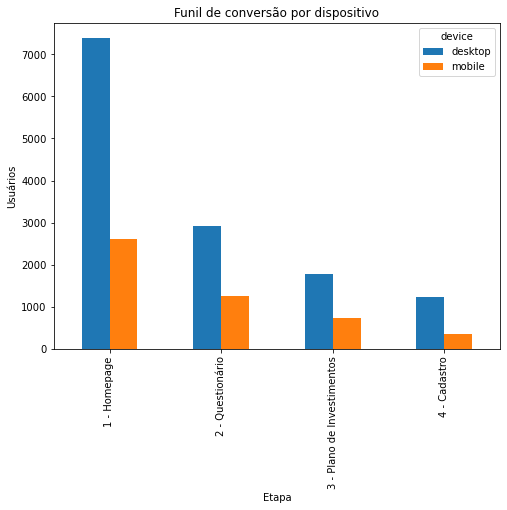

```python
conversion_funnel.groupby(['page', 'device']).size().unstack().plot(kind='bar', title='Funil de conversão por dispositivo', xlabel='Etapa', ylabel='Usuários', figsize=(8, 6))
```

Visualmente é possível notar que a diferença de cadastros entre dispositivos mobile e desktop é mais acentuada se comparada as etapas de questionário e plano de investimentos.

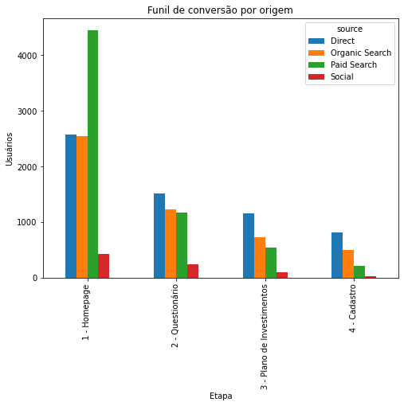

```python
conversion_funnel.groupby(['page', 'source']).size().unstack().plot(kind='bar', title='Funil de conversão por origem', xlabel='Etapa', ylabel='Usuários', figsize=(8, 6))
```

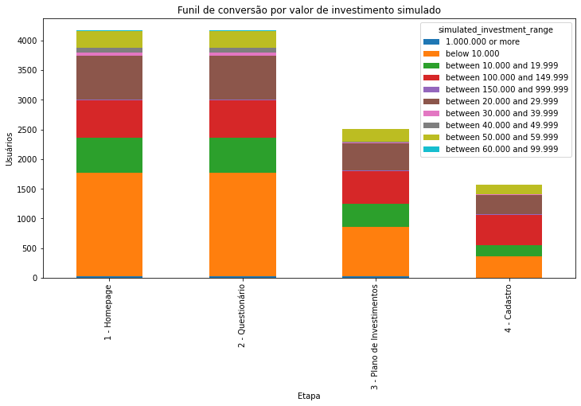

```python
conversion_funnel[conversion_funnel['simulated_investment_range'] != 'no investment'].groupby(['page', 'simulated_investment_range']).size().unstack().plot(kind='bar', stacked=True, title='Funil de conversão por valor de investimento simulado', xlabel='Etapa', ylabel='Usuários', figsize=(12, 6))
```

Pessoas que simulam investimentos:

- abaixo de **R\$ 10.000,00**.
- entre **R\$ 10.000,00 e R\\$ 20.000,00**.
- entre **R\$ 20.000,00 e R\\$ 30.000,00**.
- entre **R\$ 50.000,00 e R\\$ 60.000,00**.
- entre **R\$ 100.000,00 e R\\$ 150.000,00**.

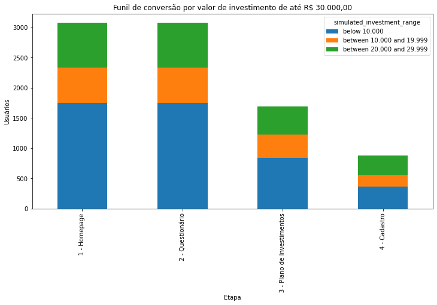

```python
conversion_funnel[(conversion_funnel['simulated_investment'] < 30000) & (conversion_funnel['simulated_investment'].notna())].groupby(['page', 'simulated_investment_range']).size().unstack().plot(kind='bar', stacked=True, title='Funil de conversão por valor de investimento de até R\\$ 30.000,00', xlabel='Etapa', ylabel='Usuários', figsize=(12, 6))
```

```python
conversion_funnel[(conversion_funnel['simulated_investment'] < 30000) & (conversion_funnel['simulated_investment'].notna())].groupby(['page']).agg({'id': ['count']})
```

| page | id count |
| --- | --- |
| 1 - Homepage | 3073 |
| 2 - Questionário | 3073 |
| 3 - Plano de Investimentos | 1691 |
| 4 - Cadastro | 883 |

```python
conversion_funnel[(conversion_funnel['simulated_investment'] >= 30000) & (conversion_funnel['simulated_investment'].notna())].groupby(['page']).agg({'id': ['count']})
```

| page | id count |
| --- | --- |
| 1 - Homepage | 1093 |
| 2 - Questionário | 1093 |
| 3 - Plano de Investimentos | 815 |
| 4 - Cadastro | 688 |

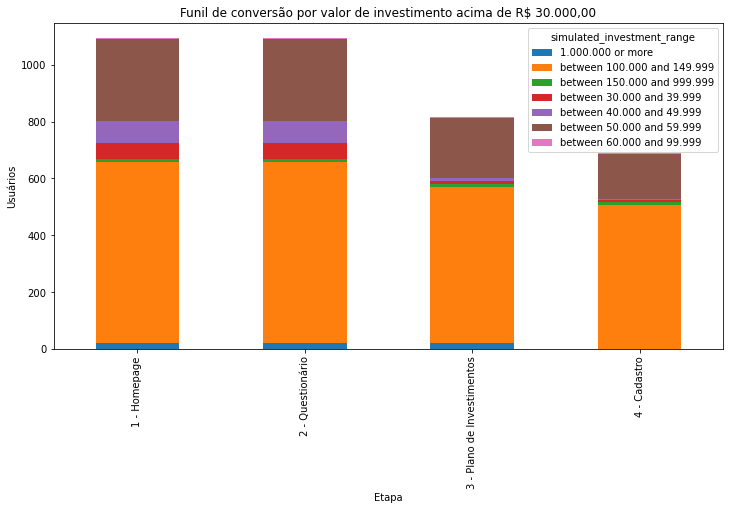

```python
conversion_funnel[(conversion_funnel['simulated_investment'] >= 30000) & (conversion_funnel['simulated_investment'].notna())].groupby(['page', 'simulated_investment_range']).size().unstack().plot(kind='bar', stacked=True, title='Funil de conversão por valor de investimento acima de R\\$ 30.000,00', xlabel='Etapa', ylabel='Usuários', figsize=(12, 6))
```

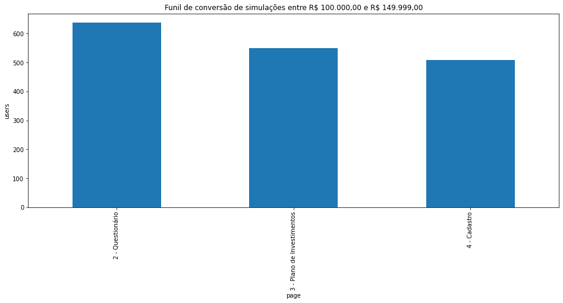

```python
conversion_funnel[(conversion_funnel['simulated_investment_range'] == 'between 100.000 and 149.999') & (conversion_funnel['page'] != '1 - Homepage')]['page'].value_counts().plot(kind='bar', title='Funil de conversão de simulações entre R\\$ 100.000,00 e R\\$ 149.999,00', xlabel='page', ylabel='users', figsize=(16, 6))
```

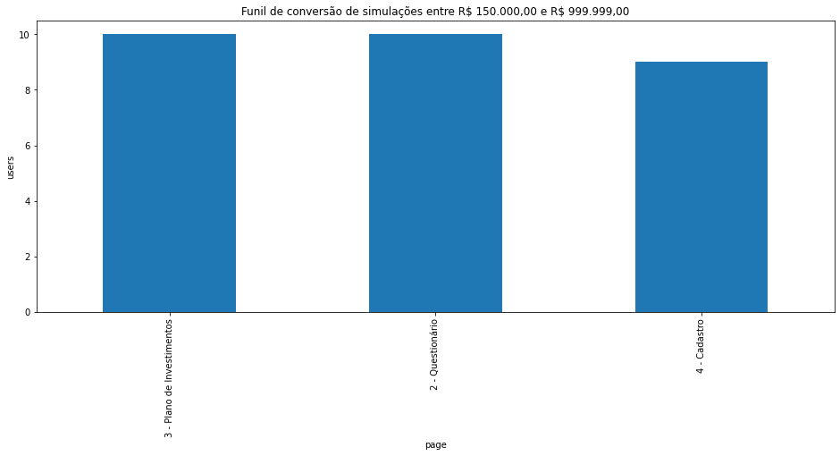

```python
conversion_funnel[(conversion_funnel['simulated_investment_range'] == 'between 150.000 and 999.999') & (conversion_funnel['page'] != '1 - Homepage')]['page'].value_counts().plot(kind='bar', title='Funil de conversão de simulações entre R\\$ 150.000,00 e R\\$ 999.999,00', xlabel='page', ylabel='users', figsize=(16, 6))
```

As taxas de conversão de quem simula investimentos acima de R\$ 150.000,00 são bem maiores que as taxas de todas as pessoas que passaram pelo funil.

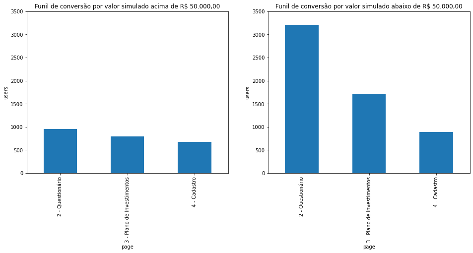

```python
fig, ax = plt.subplots(ncols=2, figsize=(16, 6))
conversion_funnel[(conversion_funnel['simulated_investment'] >= 50000) & (conversion_funnel['page'] != '1 - Homepage')]['page'].value_counts().plot(ax=ax[0], kind='bar', title='Funil de conversão por valor simulado acima de R\\$ 50.000,00', xlabel='page', ylabel='users', yticks=(0, 500, 1000, 1500, 2000, 2500, 3000, 3500))
conversion_funnel[(conversion_funnel['simulated_investment'] < 50000) & (conversion_funnel['page'] != '1 - Homepage')]['page'].value_counts().plot(ax=ax[1], kind='bar', title='Funil de conversão por valor simulado abaixo de R\\$ 50.000,00', xlabel='page', ylabel='users', yticks=(0, 500, 1000, 1500, 2000, 2500, 3000, 3500))
```

As taxas de conversão caem substancialmente quando o valor simulado é menor do que R\$ 50.000,00.

## Insights

**Perguntas iniciais**:

- Há alguma diferença significativa entre cada etapa do funil por dispositivo? E por origem? *A composição de pessoas usuárias por dispositivo no funil é de cerca de 70% desktop e 30% mobile. Esta proporção se mantém similar ao longo das etapas do funil e muda para 80% desktop e 20% mobile na última etapa*.
- O valor investido muda significativamente de acordo com a origem ou dispositivo? *O valor médio da simulação cresce a cada etapa do funil*.
- Há alguma hora do dia ou dia da semana mais comum para cadastros? *Este dado não existe na base*.
- Qual é a faixa de valores com maior número de simulações de investimento? *Entre R\$ 100.000,00 e R\\$ 150.000,00 é a faixa que mais conclui cadastros. Nas demais etapas do funil os valores simulados com maior frequência estão abaixo de R$ 10.000,00*.
- Qual é o perfil de investidor que mais faz cadastros? E quais os objetivos definidos? E o perfil / objetivo com menor taxa de conversão? *Este dado não existe na base*.

**Descobertas**:

**Novas perguntas**:

- A taxa de conversão entre os passos 1 e 2 é maior no mobile se comparada ao desktop, mas o abandono do questionário é maior no mobile. Há algum problema de usabilidade na experiência mobile?
- Quanto maior o valor de simulação mediano, maior a probabilidade de conversão no desktop?
- O volume de tráfego que entra por mídia paga no desktop é quase 4x maior que o volume de tráfego de mídia paga mobile, no entanto, o número de finalizações de funil é apenas o dobro do mobile. O tráfego de mídia impulsionada está qualificado?
- Simulações abaixo de R\$ 50.000,00 possuem taxas de conversão menores ao longo do funil. Há algo que não está tornando investimentos de baixo valor atraentes?
- A comunicação nas redes sociais está condizente com o conteúdo encontrado no site?
- Em quais questões do questionário há maior taxa de abandono?